# Bellabeat Growth Opportunities

Madelin Eliot

2023-05-13

## The Task at Hand

In order to discover new areas of growth for Bellabeat, the main question to be asked was; “How can analyzing data about smart fitness trackers help Bellabeat be more competitive?”

I wanted to use this question as a guide and narrow it down to:

- What are some trends in smart device usage?
- How could these trends apply to Bellabeat customers?
- How could these trends help influence Bellabeat marketing strategy?

## Data Sources Used

The data used (https://www.kaggle.com/datasets/arashnic/fitbit) was made available through Mobius by public domain. It included fitness tracker data from 30 eligible FitBit users. They consented to submit their personal tracker data.

The Bellabeat website (https://bellabeat.com) was also used to learn more about the company and its goals.

## Cleaning and Transforming the Data

Before performing any analysis of the data, I checked that each dataset had the variables in columns, observations in rows, and each value had its own cell.

Then, I ran clean_names() to make sure that the names in each dataset were unique and consistent.

I decided to filter out the dailyActive_merged dataset to keep only the calories and the different types of active minutes.

```r
cal_act=subset(dailyActivity_merged,select=c(Calories, VeryActiveMinutes,
                                            FairlyActiveMinutes,
                                            LightlyActiveMinutes,
                                            SedentaryMinutes))
```

## Analysis Summary

Using the cal_act dataset, I compared the different activity types; Very Active Minutes, Fairly Active Minutes, Lightly Active Minutes, and Sedentary Minutes against Calories to see if there were any trends. Specifically if the trend showed whether being active for a longer period of time was more important than the intensity.

#### Very Active Minutes vs. Calories

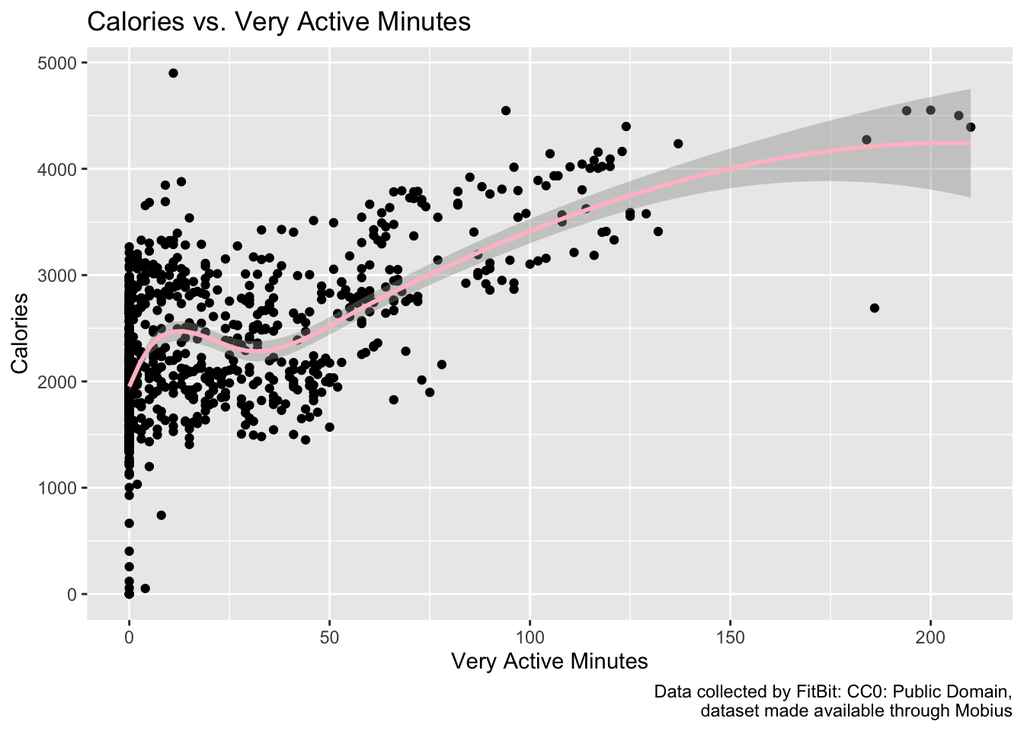

#### Fairly Active Minutes vs. Calories

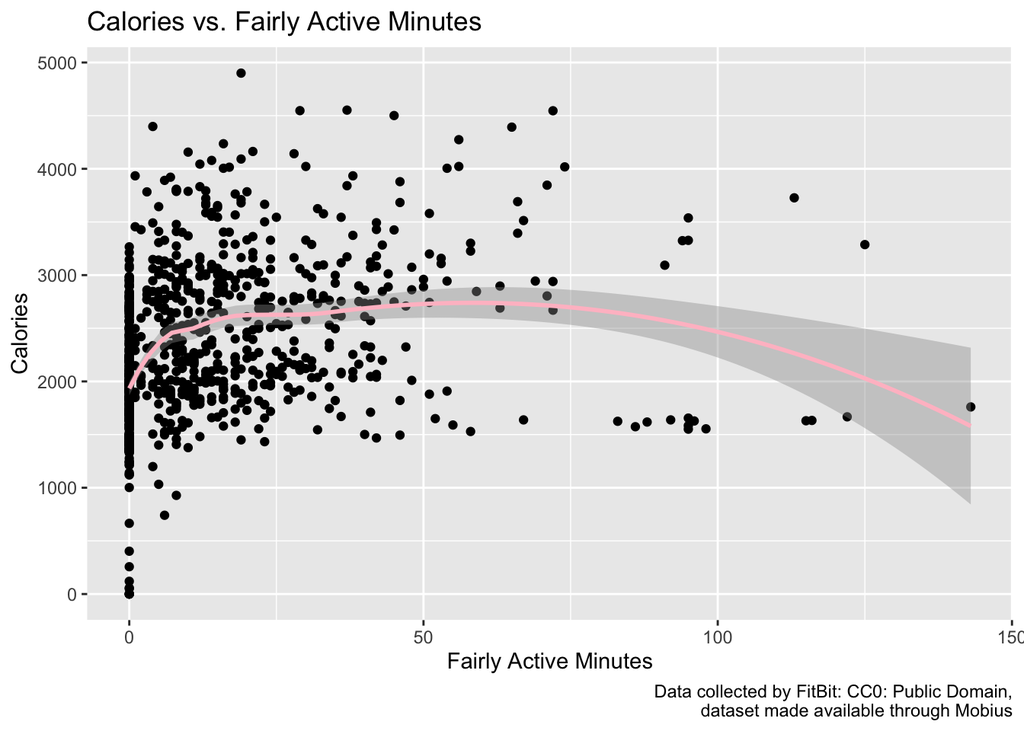

#### Lightly Active Minutes vs. Calories

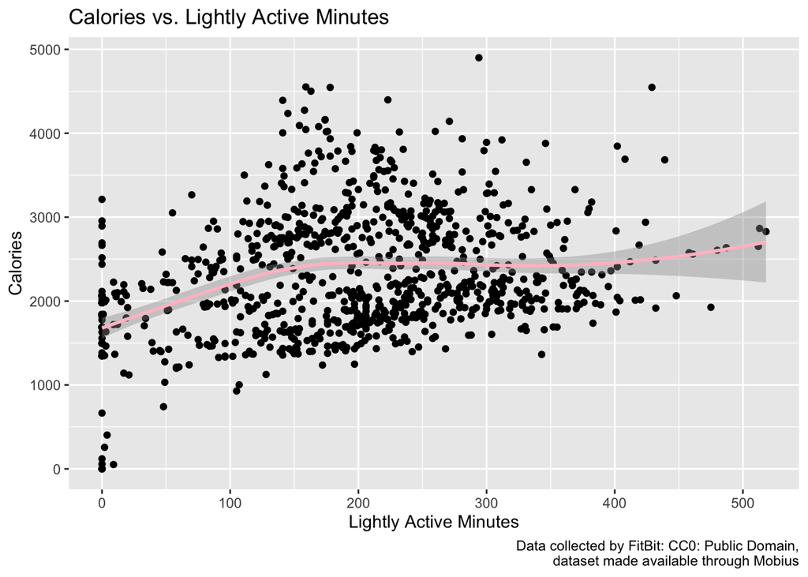

#### Sedentary Minutes vs. Calories

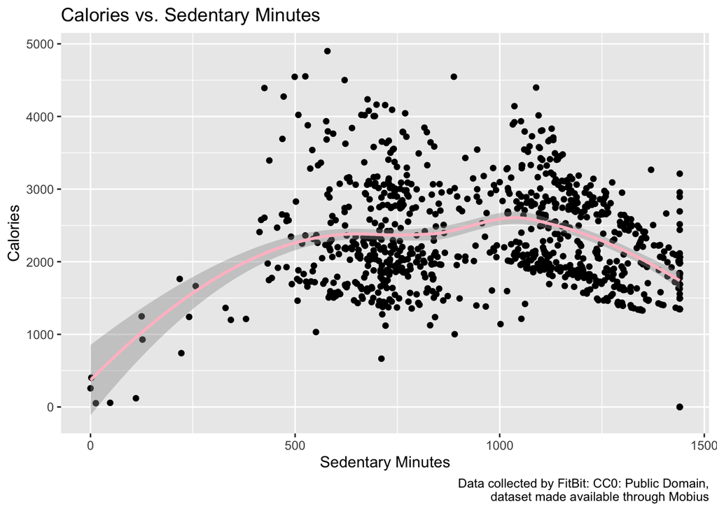

## Key Findings

After looking at the graphs, there seems to be a change in the amount of calories burned as more minutes are spent doing an activity. The change depends on the intensity of the activity.

For instance, the graph depicting sedentary minutes helps to show how our bodies naturally burn calories throughout the day, by having a gradual rise throughout the day and then slowly decreasing. Likewise, fairly active workouts have an initial rise, then become ineffective the longer they are sustained.

When looking at how effective very active workouts are, it could be that HIIT workouts burn an increased amount of calories for the first 15 minutes, but since the intensity cannot be sustained, this leads to the drop shown between the 20-25 minute mark.

Lightly active workouts appear to only moderately increase over time, which helps explain how even light movement throughout the day is better than no movement at all.

## Recommendations

Since every body is different, these findings might not apply to all. However, I think these findings are a good, general representation of how different kinds of workouts can each be effective.

Since the Leaf already tracks how many minutes are spent being active, I think Bellabeat could use this as a chance to grow. Implementing software that not only tracks the minutes, but also the intensity level, of a workout could inform their users how the type of activity they are performing is effecting their goal(s).

Then, the Leaf could offer recommendations on if they should switch things up or continue with the routine. This way, users are getting up-to-date feedback on how they are going about accomplishing their goals.

Another recommendation can be pulled from the graph comparing Calories to Very Active Minutes. The Leaf could be upgraded to track how effective the workout is while it is happening. When the calories burned starts to decrease, the Leaf could alert the user that it is time to switch to something more sustainable or signal the end of a workout.

I think that these recommendations would give Bellabeat an edge in the smart device market. It would be like having a personal trainer constantly monitoring the progress, letting users avoid activities that are not right for them or recommending ways to introduce variety.